# Multiple Testing Project

## 2.2 P-value

## 1. Distribution of the p-value under the null

**1.1 Show that for any $\alpha$, $c_{\alpha} = F_{H}^{-1}(1 - \alpha)$**

We know that $\alpha = 1 - F_{H}(c_{\alpha})$ from the definition of $c_{\alpha}$.

$\alpha = 1 - F_{H}(c_{\alpha})$

$\alpha - 1 = - F_{H}(c_{\alpha})$

$-(\alpha - 1) = F_{H}(c_{\alpha})$

$1 - \alpha = F_{H}(c_{\alpha})$

$F^{-1}_{H}(1 - \alpha) = c_{\alpha}$

$c_{\alpha} = F^{-1}_{H}(1 - \alpha)$

Q.E.D.

**1.2 Show that the p-value of the test, as a function of the data X used, is given by $p(\textbf{X}) = 1 - F_{H}(T(\textbf{X}))$.**

The p-value is defined as $p-value = inf\{\alpha : T(X) \in R_{\alpha}\}$

Which is to say that the p-value is the *smallest* $\alpha$ for which $T(X)$ is in the region $R_{\alpha}$ of the probability distribution $P_{H}$

So the p-value is an instance of $\alpha$, which is defined as $\alpha = 1 - F_{H}(c_{\alpha})$ where $c_{\alpha}$ is chosen so that the equation is true. Therefore, if we replace $c_{\alpha}$ with our test statistic $T(\textbf{X})$, we get a $p(\textbf{X}) = 1 - F_{H}(T(\textbf{X}))$.

This matters because it highlights that the choice of $\alpha$ sets the minimum p-value for $\textbf{X}$ as $p(\textbf{X})$ such that one rejects the hypothesis that X is from the same distribution as Y when $T(\textbf{X}) > c_{\alpha}$.

**1.3 Show that for any univariate random variable $y$ with continuous distribution function $F$, the random variables $F(y)$ and $1 - F(y)$ follow the uniform distribution.**

We know a function to be uniformly distributed if it has constant probability in the range for which it is defined. Say $y_{i}$ is some value for which $F_{Y}(y_{i})$ is defined. The set of all $y_{i}$ is denoted as $\textbf{Y}$ and the probability of $F_{Y}(\textbf{Y})$ is given by $P[F_{Y}(\textbf{Y})]$.

$F_{Y}$ is uniformly distributed when $P[F_{Y}(y_{1})] = P[F_{Y}(y_{2})]$ where $y_{1} y_{2}$ are any 2 values in $\textbf{Y}$.

$P[F_{Y}(\textbf{Y}) \leq y] = P[F^{-1}(F_{Y}(\textbf{Y})) \leq F^{-1}(y)] = P[\textbf{Y} \leq F^{-1}(y)]$

We know that $F_{Y}$ is strictly increasing $F^{-1}_{Y}(F_{Y}(\textbf{Y})) = y$ by the definition of the definition of a quantile function which is the generalized inverse of a CDF. We use this property to concolude:

$P[\textbf{Y} \leq F^{-1}_{Y}(y)] = F_{Y}(F^{-1}_{Y}(y)) = y$

This is true for all values of $\textbf{Y}$.

By definition if a function $F_{Y}$ follows the uniform distribution, so does $1 - F_{Y}$

**1.4 Using the above results, show that the p-value follows the uniform distribution under H.**

$\alpha = 1 - F_{H}(c_{\alpha})$

$c_{\alpha}$ being a continuous random variable, we know $F_{H}(c_{\alpha})$ to have a uniform distribution. If $F_{H}(c_{\alpha})$ follows a uniform distribution, $1 - F_{H}(c_{\alpha})$ does too.

## MT under independence assumptions

**2.1 Show that $P_{H}[\cap^{m}_{i = 1} \{ y_{i} > \alpha \} ] = (1 - \alpha)^{m}$**

As $y_{1},..., y_{m}$ are unifrom random variables between 0 and 1, we can state that $p(y_{i}) > \alpha$ is equivalent to $y_{i} > \alpha$. As they are independent, the joint distribution of the probability that for every $y_{i}$ the condition $y_{i} > \alpha$ holds is nothing but the product of the probabilities,

$P_{H}[\cap^{m}_{i = 1} \{ y_{i} > \alpha \} ] = \prod_{i=1}^{m}P(y_{i} > \alpha)$

We know from the previous exercises that $P(T(y_{i}) < \alpha) = \alpha$, or, equivalently, $P(p(y_{i}) > \alpha) = 1 - \alpha$. In this case, with uniformly distributed $y_{i}$, it is equivalent to say that $P(y_{i} > \alpha) = 1 - \alpha$. Therefore,

$\prod_{i=1}^{m}P(y_{i} > \alpha) = (1 - \alpha)^{m}$

**2.2 Show that the probability of rejecting at significance level $\alpha$ at least one of the independent tests is $1 - ( 1 - \alpha)^{m}$.**

The probability of rejecting at least one of the tests could be expressed as the union,

$P_{H}[\cup^{m}_{i = 1} \{ y_{i} < \alpha \} ]$

And we know that the probability of at least one rejection is the complement of the probability of having no rejections, which we have already determined as being equal to $(1 - \alpha)^{m}$. Thus,

$P_{H}[\cup^{m}_{i = 1} \{ y_{i} < \alpha \} ] = 1 - P_{H}[\cap^{m}_{i = 1} \{ y_{i} > \alpha \} ]$

$P_{H}[\cup^{m}_{i = 1} \{ y_{i} < \alpha \} ] = 1 - (1 - \alpha)^{m}$

**2.3 Under the above assumption, show that if we wish that the overall type I error is $\alpha$, each independent test should be rejected at significance level $1 - (1 - \alpha)1/m$**

$1 - (1 - \alpha)^{m}$

So if we want the overall type I error to be $\alpha$ for m tests, each test should be rejected at a certain probability $p_{r}$ that satisfies:

$P_{H}[\cup^{m}_{i = 1} \{ y_{i} < p_{r} \} ] = 1 - (1 - p_{r})^{m} = \alpha$

Solving for $p_{r}$ to determine the level $p_{r}$ at which each test should be evaluated:

$1 - (1 - p_{r})^{m} = \alpha$

$p_{r} = 1 - (1 - \alpha)^{\frac{1}{m}}$

**2.4 For $\alpha \in [0,1]$, check that $f_{2} \leq f_{1} \leq f_{3}$.**

$f_{1}(\alpha) = 1 - (1 - \alpha)^{\frac{1}{m}}$

$f_{2}(\alpha) = \frac{\alpha}{m}$

$f_{3}(\alpha) = \alpha$

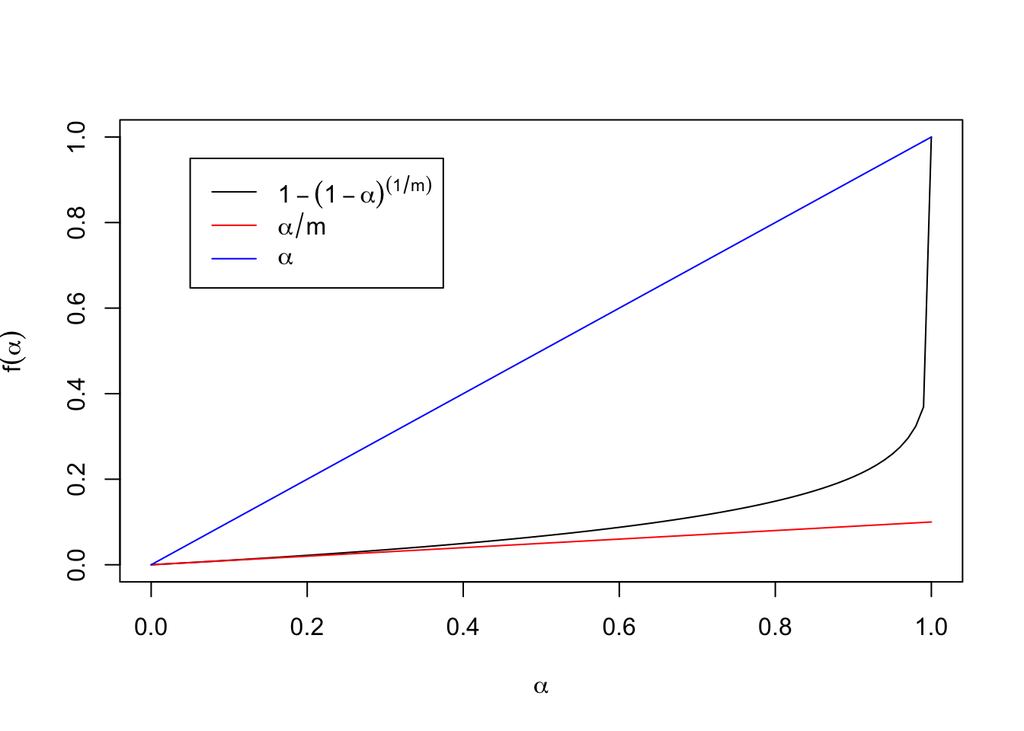

**2.5** (optional)

We can say $f_{1} \leq f_{3}$ from the following:

$1-(1 - \alpha)^{\frac{1}{m}} \leq \alpha$

$1-(1 - \alpha)^{\frac{1}{m}} - \alpha \leq 0$

We know the expression $(1 - \alpha)^{\frac{1}{m}}$ when $m = 1$ because $m \in [1,\inf]$ and $1 - \alpha \in [0,1]$, and a fraction raised to a fraction is a greater fraction, increasing with the denominator of the exponent.

So the minimum value of $1-(1 - \alpha)^{\frac{1}{m}} - \alpha$ is given by $m = 1$ and

$1 - 1 + \alpha - \alpha = 0 \leq 0$, and $f_{1} \leq f_{3}$ Q.E.D.

We can say $f_{2} \leq f_{1}$ from the following:

$\frac{\alpha}{m} \leq 1-(1 - \alpha)^{\frac{1}{m}}$

$0 \leq m - m(1 - \alpha)^{1/m} - \alpha$

The expression $m - m(1 - \alpha)^{1/m}$ will always be less than or greater than alpha because as described above, a fraction raised a fraction is a greater fraction so the difference in these two terms $m$ and $m - m(1 - \alpha)^{1/m}$ is always greater than $\alpha$ and the difference increases with m. The minimum of m is 1 so for further proof, we can take the minimum to be:

$0 \leq 1 - (1 - \alpha) - \alpha = 0$ Q.E.D.

**2.6: Conclude that, under the independence assumptions, the level needed for each test can be determined and it is smaller than the approach that makes no correction for multiple testing.**

In 2.3 it was shown the level needed for each test is $p_{r} = 1 - (1 - \alpha)^{\frac{1}{m}}$ in order to achieve a level of $\alpha$ for multiple tests. The level that makes no correction for multiple testing is assuming $m = 1$:

No correction: $p_{uncorrected} = 1 - (1 - \alpha)$

Corrected: $p_{corrected} = 1 - (1 - \alpha)^{\frac{1}{m}}$

We want to show that $p_{corrected} \leq p_{uncorrected}$

$1 - (1 - \alpha)^{\frac{1}{m}} \leq 1 - (1 - \alpha)$

$-(1 - \alpha)^{\frac{1}{m}} \leq -(1 - \alpha)$ Multiplying both sides by -1, we reverse the sign.

$(1 - \alpha)^{\frac{1}{m}} \geq (1 - \alpha)$

Since $m \in [1,\inf]$ and $\alpha \in [0,1]$, this comparison is always true.

## A conservative but robust test: Bonferroni

**3. Upper-bounding the probability of at least one rejection.**

Show that $\alpha \leq P_{C - H}[\cup^{m}_{i=1} \{ p_{i}(Y_{i}) < \alpha \}] \leq m \alpha$

Using Boole’s inequality we can say that:

$P_{C - H}[\cup^{m}_{i=1} \{ p_{i}(Y_{i}) < \alpha \}] \leq \sum^{m}_{i=1} P(p_{i}(Y_{i}) < \alpha)$

From section 1 of the project we know that $P(P(p_{i}(Y_{i}) < \alpha) = \alpha$. Therefore, $\sum^{m}_{i=1} P(p_{i}(Y_{i}) < \alpha) = m \alpha$.

Hence, we have proved the upper bound $P_{C - H}[\cup^{m}_{i=1} \{ p_{i}(Y_{i}) < \alpha \}] \leq m \alpha$.

The lower bound of $\alpha$ turns into an equality at $P_{C - H}[\cup^{m}_{i=1} \{ p_{i}(Y_{i}) < \frac{\alpha}{m} \}]$, since, solving for $p_{size}$,

$P_{C - H}[\cup^{m}_{i=1} \{ p_{i}(Y_{i}) < p_{size} \}] \leq \sum^{m}_{i=1} P(p_{i}(Y_{i}) < p_{size}) = \alpha$

$m p_{size} = \alpha$

$p_{size} = \frac{\alpha}{m}$

This means that using a threshold probability of $\frac{\alpha}{m}$ for rejecting each individual test ensures that the overall type I error equals $\alpha$.

Now, if $\alpha = P_{C - H}[\cup^{m}_{i=1} \{ p_{i}(Y_{i}) < \frac{\alpha}{m} \}]$, for any $p_{size} \geqslant \frac{\alpha}{m}$ such as $p_{size} = \alpha$, $\alpha \leq P_{C - H}[\cup^{m}_{i=1} \{ p_{i}(Y_{i}) < p_{size} \}]$, proving the lower bound, which will obsiusly turn into an equality when we only test once ($m = 1$). Alternatively, it is easy to see that for any set of events $A_{i}$ where $i \in [1,m]$, $P(A_{1}) \leqslant P(\cup^{m}_{i=1}A_{i})$. In this case, event $i$ is $P(p_{i}(Y_{i}) < \alpha)$.

### Ordered p-values, family-wise error rate and a new MT correction

**4. Show that under the complete null the probability of at least one false rejection is $\alpha$**

If we reject test $i$ when $p_{(i)} < \frac{i \alpha}{m}$, as long as $y_{i}$ follow a uniform distribution between 0 and 1, we can also state that we reject test $i$ when $y_{i} < \frac{i \alpha}{m}$. Thus, the probability of at least one false rejection is:

$P_{H}[\cup^{m}_{i = 1} \{ y_{i} < \frac{i \alpha}{m} \} ]$

The probability of none of the tests being rejected is the complement of at least one rejection.

$P_{H}[\cup^{m}_{i = 1} \{ y_{i} < \frac{i \alpha}{m} \} ] = 1 - P_{H}[\cap^{m}_{i = 1} \{ y_{i} > \frac{i \alpha}{m} \} ]$

And we know that $P_{H}[\cap^{m}_{i = 1} \{ y_{i} > \frac{i \alpha}{m} \} ] = 1 - \alpha$. Therefore,